# Ames Housing Project

# Préparation du Jeu de Données : Nettoyage et Gestion des Valeurs Manquantes

### 1/Supprimer l’espace dans le nom du colonne:

```r
names(df) <- gsub(" ", "", names(df))
```

### 2/Supprimer la colonne PID(ID):

```r
df$PID <- NULL
```

Verifier que la colonne a ete supprime:

```r
dim(df)
```

```
[1] 2930   81
```

### 3/Gérer les valeurs manquantes:

```r
# Calculer le pourcentage de valeurs manquantes
pourcentage <- colSums(is.na(df)) / nrow(df) * 100

# Afficher les colonnes avec des valeurs manquantes et leur pourcentage
pourcentage[pourcentage > 0][order(-pourcentage[pourcentage > 0])]
```

```
       Pool.QC   Misc.Feature          Alley          Fence
   99.55631399    96.38225256    93.24232082    80.47781570
  Fireplace.Qu   Lot.Frontage  Garage.Yr.Blt    Garage.Qual
   48.53242321    16.72354949     5.42662116     5.39249147
   Garage.Cond    Garage.Type  Garage.Finish      Bsmt.Qual
    5.39249147     5.35836177     5.35836177     2.69624573
     Bsmt.Cond  Bsmt.Exposure BsmtFin.Type.1 BsmtFin.Type.2
    2.69624573     2.69624573     2.69624573     2.69624573
  Mas.Vnr.Area Bsmt.Full.Bath Bsmt.Half.Bath   BsmtFin.SF.1
    0.78498294     0.06825939     0.06825939     0.03412969
  BsmtFin.SF.2    Bsmt.Unf.SF  Total.Bsmt.SF    Garage.Cars
    0.03412969     0.03412969     0.03412969     0.03412969
   Garage.Area
    0.03412969
```

#### a- Si une colonne a plus de 40% de valeurs manquantes, on la supprime:

```r
# Identifier les colonnes avec plus de 40% de valeurs manquantes
colonnes_supprimer <- names(pourcentage[pourcentage > 40])

# Supprimer les colonnes avec plus de 40% de valeurs manquantes
df <- df[, !(names(df) %in% colonnes_supprimer)]
```

#### b- Pour les colonnes ayant moins de 40% de valeurs manquantes, on remplace les valeurs manquantes par la médiane (pour les variables numériques) ou le mode (pour les variables catégorielles) :

```r
for (col in names(df)) {
  if (any(is.na(df[[col]]))) {
    if (is.numeric(df[[col]])) {
      # Remplacer les NA par la médiane pour les colonnes numériques
      df[[col]][is.na(df[[col]])] <- median(df[[col]], na.rm = TRUE)
    } else {
      # Remplacer les NA par la valeur la plus fréquente (mode) pour les colonnes catégorielles
      mode_val <- names(sort(table(df[[col]]), decreasing = TRUE))[1]
      df[[col]][is.na(df[[col]])] <- mode_val
    }
  }
}
```

#### c- Verification :

```r
# Calculer le pourcentage de valeurs manquantes
pourcentage <- colSums(is.na(df)) / nrow(df) * 100

# Afficher les colonnes avec des valeurs manquantes et leur pourcentage
pourcentage[pourcentage > 0][order(-pourcentage[pourcentage > 0])]
```

```
named numeric(0)
```

#### –> Aucune valeur manquante.

### 4/Gérer les doublons:

```r
doublons <- sum(duplicated(df))
print(doublons)
```

```
[1] 0
```

#### –> Il n’y a aucune ligne dupliquée dans le DataFrame

# Paramètres statistiques usuels

### 1/Table de statistiques descriptives:

```r
summary(df)
```

```
     Order         MS.SubClass      MS.Zoning
 Min.   :   1.0   Min.   : 20.00   Length:2930
 1st Qu.: 733.2   1st Qu.: 20.00   Class :character
 Median :1465.5   Median : 50.00   Mode  :character
 Mean   :1465.5   Mean   : 57.39
 3rd Qu.:2197.8   3rd Qu.: 70.00
 Max.   :2930.0   Max.   :190.00
  Lot.Frontage       Lot.Area         Street
 Min.   : 21.00   Min.   :  1300   Length:2930
 1st Qu.: 60.00   1st Qu.:  7440   Class :character
 Median : 68.00   Median :  9436   Mode  :character
 Mean   : 69.02   Mean   : 10148
 3rd Qu.: 78.00   3rd Qu.: 11555
 Max.   :313.00   Max.   :215245
  Lot.Shape         Land.Contour        Utilities
 Length:2930        Length:2930        Length:2930
 Class :character   Class :character   Class :character
 Mode  :character   Mode  :character   Mode  :character



  Lot.Config         Land.Slope        Neighborhood
 Length:2930        Length:2930        Length:2930
 Class :character   Class :character   Class :character
 Mode  :character   Mode  :character   Mode  :character



 Condition.1        Condition.2         Bldg.Type
 Length:2930        Length:2930        Length:2930
 Class :character   Class :character   Class :character
 Mode  :character   Mode  :character   Mode  :character



 House.Style         Overall.Qual     Overall.Cond
 Length:2930        Min.   : 1.000   Min.   :1.000
 Class :character   1st Qu.: 5.000   1st Qu.:5.000
 Mode  :character   Median : 6.000   Median :5.000
                    Mean   : 6.095   Mean   :5.563
```

[output cut: 127 more lines]

```
 Max.   :800.000   Max.   :17000.00   Max.   :12.000
    Yr.Sold      Sale.Type         Sale.Condition
 Min.   :2006   Length:2930        Length:2930
 1st Qu.:2007   Class :character   Class :character
 Median :2008   Mode  :character   Mode  :character
 Mean   :2008
 3rd Qu.:2009
 Max.   :2010
   SalePrice
 Min.   : 12789
 1st Qu.:129500
 Median :160000
 Mean   :180796
 3rd Qu.:213500
 Max.   :755000
```

# Paramètres statistiques usuels

# Analyses univariées

## Catégorielles :

1 - La variable Neighborhood représente le quartier où se situe chaque maison dans la ville d’Ames. C’est une variable catégorielle avec plusieurs modalités, chacune correspondant à un quartier différent.

```r
table(df$Neighborhood)
```

```
Blmngtn Blueste  BrDale BrkSide ClearCr CollgCr Crawfor
     28      10      30     108      44     267     103
Edwards Gilbert  Greens GrnHill  IDOTRR Landmrk MeadowV
    194     165       8       2      93       1      37
Mitchel   NAmes NoRidge NPkVill NridgHt  NWAmes OldTown
    114     443      71      23     166     131     239
 Sawyer SawyerW Somerst StoneBr   SWISU  Timber Veenker
    151     125     182      51      48      72      24
```

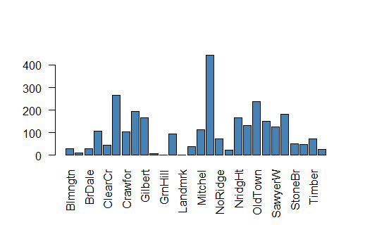

```r
barplot(table(df$Neighborhood), las=2, col="steelblue")
```

#### –> Le résultat montre combien de maisons sont présentes dans chaque quartier du dataset. Par exemple :

- Le quartier NAmes contient 443 maisons, c’est le plus représenté.
- CollgCr en a 267, OldTown en a 239, etc.
- Certains quartiers comme Landmrk ou GrnHill ont très peu d’observations (1 ou 2 maisons).